# QC-espresso

Quality control report for DIA proteomics data

Author

Guilherme Lanfredi

Published

November 3, 2026

Abstract

This report provides a structured quality control assessment of data-independent acquisition (DIA) proteomics experiments processed with DIA-NN. The analysis supports instrument performance monitoring, dataset validation, and longitudinal QC tracking. QC-espresso is an open-source workflow implemented in R and Quarto.

**NoteQC-espresso resources**

The source code, documentation, example data, and portable Windows release are available in the [QC-espresso GitHub repository](https://github.com/lanfredig/QC-espresso_DIA).

If you find QC-espresso useful in your research, please cite the associated publication: [*QC-espresso: Brewing quality in proteomics*](https://doi.org/10.64898/2026.10.29.762921).

# 1. Identification performance

**NoteIdentification depth**

This section reports **identification depth per run** at the **precursor**, **modified peptide sequence**, and **protein‑group** levels.

These levels capture complementary aspects of identification performance: precursor counts distinguish charge‑ and modification‑specific precursor forms, modified peptide sequences retain sequence and modification information, and protein groups summarize identification at the inference level used for downstream analyses.

Horizontal reference lines indicate the **mean identification count across runs** (blue dotted), the **maximum identification count observed in a single run** (red dotted), and the **total number of distinct identifiers across the complete filtered dataset** (purple solid) for each level. The dataset-wide total counts each identifier only once, even when it occurs in multiple runs. These descriptive references should be interpreted together with chromatographic, intensity, and completeness QC metrics.

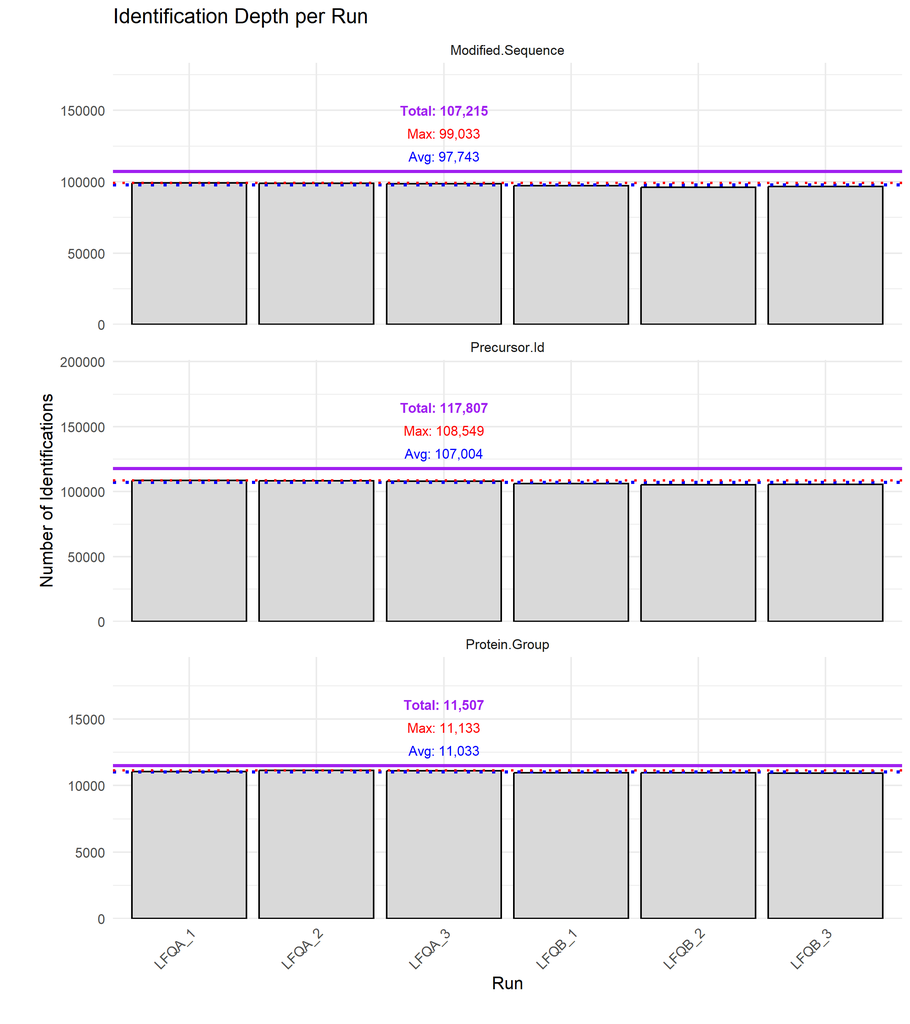

Identification Depth per Run

Precursors, peptides, and protein groups

| Run | Precursors | Peptides | Protein.Groups |
| --- | --- | --- | --- |
| LFQA_1 | 108,549 | 99,033 | 11,061 |
| LFQA_2 | 108,186 | 98,781 | 11,133 |
| LFQA_3 | 108,080 | 98,647 | 11,121 |
| LFQB_1 | 106,334 | 97,135 | 10,973 |
| LFQB_2 | 105,204 | 96,185 | 10,966 |
| LFQB_3 | 105,673 | 96,679 | 10,946 |

TOTAL across all runs - Peptides: 107,215; Precursors: 117,807; Protein Groups: 11,507

# 2. Quantitative signal composition

**NoteRelative abundance and contaminant contribution**

This section summarizes the **relative composition of protein-group signal within each run**, calculated by summing positive `Precursor.Quantity` values for each original `Protein.Group`. FASTA-derived gene or accession labels are used for visualization without redistributing quantitative signal among individual accessions. The ten annotation labels with the highest total signal across the filtered dataset are displayed individually, while the remaining labels are grouped as **Others**.

Relative signal-composition profiles provide a concise assessment of sample composition and quantitative balance between runs. Consistent patterns may indicate stable sample preparation and instrument response, whereas pronounced shifts may reflect differences in sample loading, sample composition, preparation, acquisition, background contamination, or overall signal balance.

When protein groups containing recognized `CON_` or `cRAP-` accession prefixes and positive quantitative signal are available, an additional plot highlights signal associated with annotated contaminants, which may include keratins, proteolytic enzymes, and other common laboratory contaminants. The plot shows the **relative composition of contaminant signal within each run**, while the accompanying label reports the fraction of total run signal assigned to these recognized contaminants. If the recognized prefixes or positive contaminant signal are unavailable, the contaminant plot is omitted and an explanatory notice is displayed.

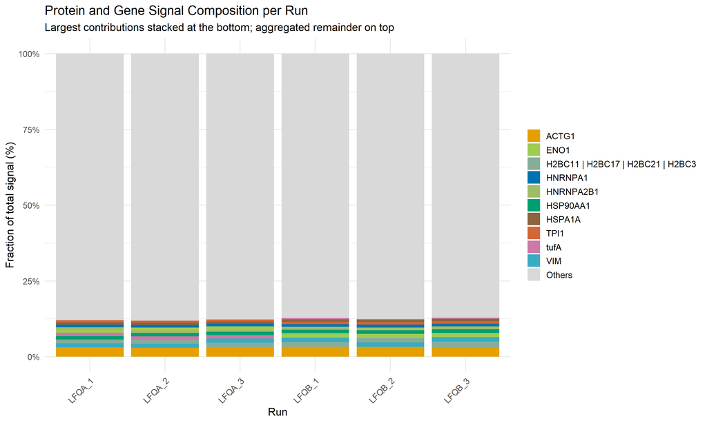

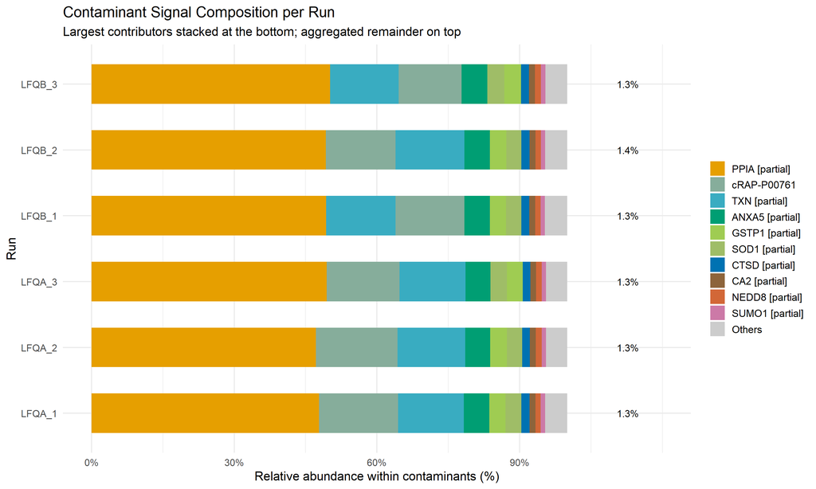

# 3. Sequence coverage

**NoteProtein sequence coverage**

This section summarizes **protein sequence coverage** based on exact matching of identified peptides to reference protein sequences.

Coverage reflects the fraction of amino acid positions supported by at least one mapped peptide. All occurrences of each unique peptide are considered, while overlapping peptide mappings do not result in duplicate counting of covered residues. The summary table reports the **top 100 reference proteins** ranked by sequence coverage, while the density plot provides an overview of the coverage distribution among proteins with positive sequence coverage.

The exported CSV file includes proteins with at least one covered amino acid position, together with their mapped peptide evidence. Proteins without mapped peptide evidence remain represented in the complete in-memory coverage table but are not included in the exported CSV. Sequence coverage complements identification depth by describing how extensively individual reference protein sequences are sampled rather than how many proteins are detected.

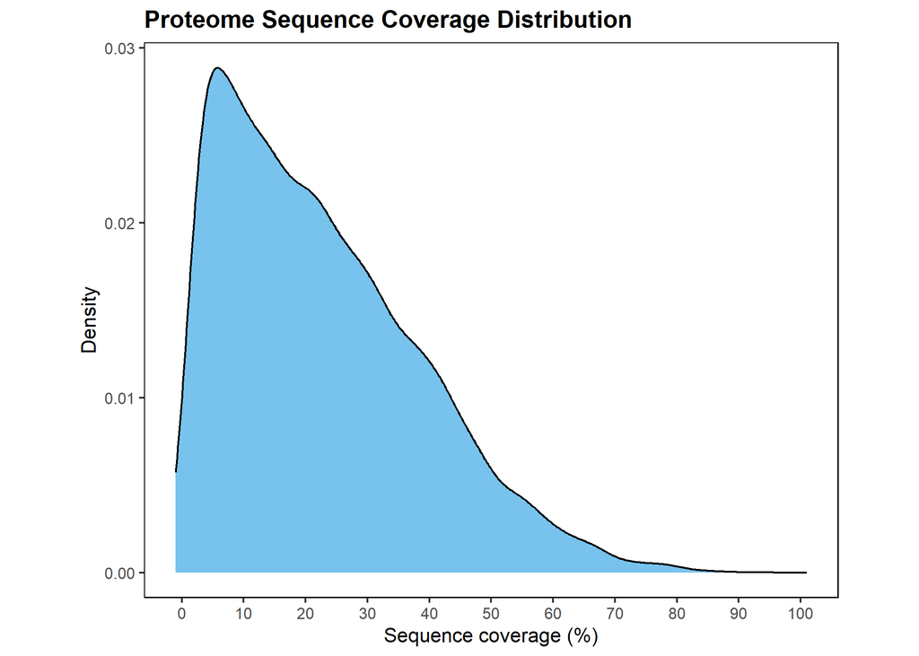

Protein Sequence Coverage Summary (Top 100)

Mapped peptide evidence for covered proteins is exported as CSV

| Accession | Protein Name | Length (aa) | Covered AA | Coverage (%) |
| --- | --- | --- | --- | --- |
| P0AB61 | Protein YciN | 83 | 74 | 89.2% |
| P60174 | Triosephosphate isomerase | 249 | 215 | 86.3% |
| P04075 | Fructose-bisphosphate aldolase A | 364 | 311 | 85.4% |
| O75368 | Adapter SH3BGRL | 114 | 97 | 85.1% |
| P10599 | Thioredoxin | 105 | 89 | 84.8% |
| P00445 | Superoxide dismutase [Cu-Zn] | 154 | 127 | 82.5% |
| Q9Y333 | U6 snRNA-associated Sm-like protein LSm2 | 95 | 78 | 82.1% |
| P68066 | Autonomous glycyl radical cofactor | 127 | 104 | 81.9% |
| P41227 | N-alpha-acetyltransferase 10 | 235 | 192 | 81.7% |
| O95777 | U6 snRNA-associated Sm-like protein LSm8 | 96 | 78 | 81.2% |
| P21796 | Non-selective voltage-gated ion channel VDAC1 | 283 | 228 | 80.6% |
| O43715 | TP53-regulated inhibitor of apoptosis 1 | 76 | 61 | 80.3% |
| P0AF36 | Cell division protein ZapB | 81 | 65 | 80.2% |
| P04080 | Cystatin-B | 98 | 78 | 79.6% |
| P0AC62 | Glutaredoxin 3 | 83 | 66 | 79.5% |
| Q9BSY4 | Coiled-coil-helix-coiled-coil-helix domain-containing protein 5 | 110 | 87 | 79.1% |
| P0ACD4 | Iron-sulfur cluster assembly scaffold protein IscU | 128 | 101 | 78.9% |
| P22943 | 12 kDa heat shock protein | 109 | 86 | 78.9% |
| P08758 | Annexin A5 | 320 | 252 | 78.8% |
| P68919 | Large ribosomal subunit protein bL25 | 94 | 74 | 78.7% |
| Q96EL3 | Large ribosomal subunit protein mL53 | 112 | 88 | 78.6% |
| P40037 | Protein HMF1 | 129 | 101 | 78.3% |
| P0A972 | Cold shock-like protein CspE | 69 | 54 | 78.3% |
| Q02790 | Peptidyl-prolyl cis-trans isomerase FKBP4 | 459 | 359 | 78.2% |
| P80723 | Brain acid soluble protein 1 | 227 | 177 | 78% |
| P56277 | Cx9C motif-containing protein 4 | 68 | 53 | 77.9% |
| P19623 | Spermidine synthase | 302 | 235 | 77.8% |
| Q99497 | Parkinson disease protein 7 | 189 | 147 | 77.8% |
| Q9H2H8 | Peptidyl-prolyl cis-trans isomerase-like 3 | 161 | 125 | 77.6% |
| P62888 | Large ribosomal subunit protein eL30 | 115 | 89 | 77.4% |

[output cut: 70 more lines]

# 4. Peptide-level quality

**NotePeptide‑level metrics**

This section summarizes **peptide‑level quality metrics** across runs, including precursor **charge‑state distribution**, **peptide length**, and **missed tryptic cleavages**.

Charge‑state distributions are calculated from distinct combinations of run, precursor identifier, and precursor charge. Peptide length and missed‑cleavage metrics are calculated from distinct stripped peptide sequences within each run. Peptide length distributions include the median length per run, while digestion efficiency is assessed through the fraction of unique stripped peptide sequences containing at least one missed tryptic cleavage.

A missed cleavage is assigned when an internal lysine or arginine is not followed by proline, while a terminal lysine or arginine is not counted as a missed cleavage. Together, these metrics provide complementary information to identification counts by capturing variation in precursor charge, peptide length, and digestion performance that may not be evident at the protein‑group level.

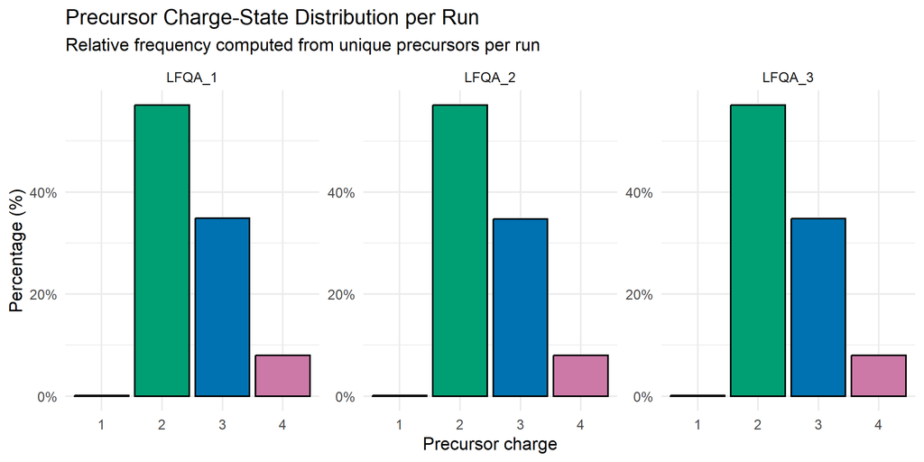

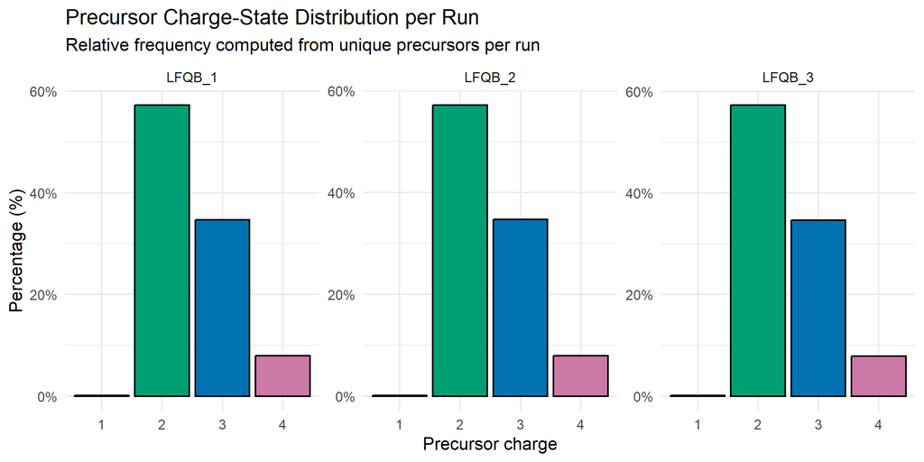

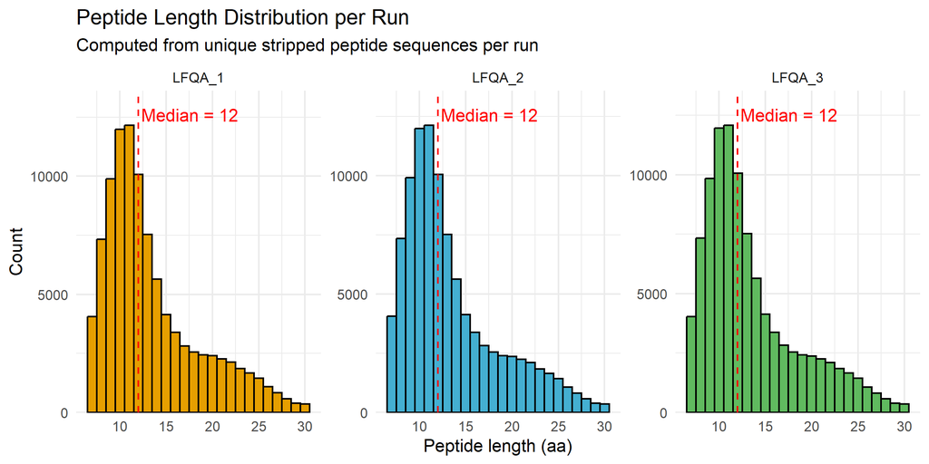

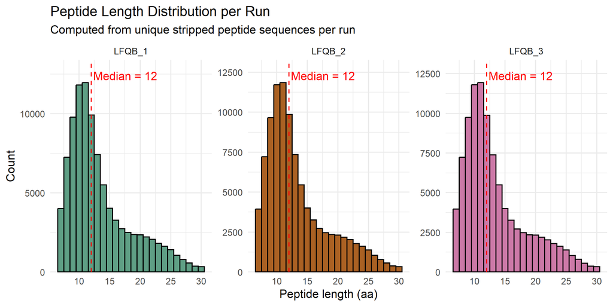

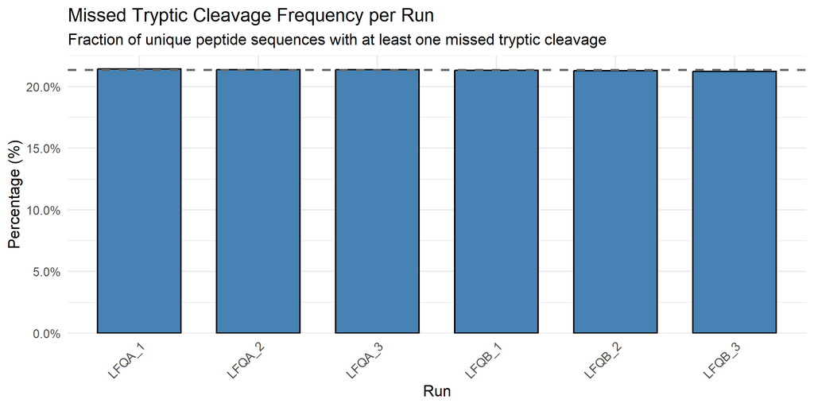

# 5. Chromatographic performance

**NoteChromatography quality**

This section evaluates **chromatographic performance and retention‑time behavior** across runs using the distribution of retained DIA‑NN report entries over retention time, peak width metrics, and monitoring of trypsin autolysis precursors.

The distribution of retained report entries over retention time summarizes how quantitative precursor-level observations are distributed across the LC gradient, providing an overview of gradient utilization and run‑to‑run stability. Peak width metrics, including **full width at half maximum (FWHM)** and **peak base width**, are reported in seconds and characterize chromatographic peak width and separation performance. Median FWHM and peak base width values are indicated for each run.

Retention‑time reproducibility and quantitative signal stability are additionally assessed for three predefined **trypsin autolysis precursors**, which serve as internal process references for digestion, chromatography, and acquisition performance. These measurements may still be influenced by sample preparation, digestion efficiency, matrix composition, and signal availability. Together, the plots can reveal patterns consistent with gradient drift, peak broadening, altered chromatographic separation, or reduced run‑to‑run stability.

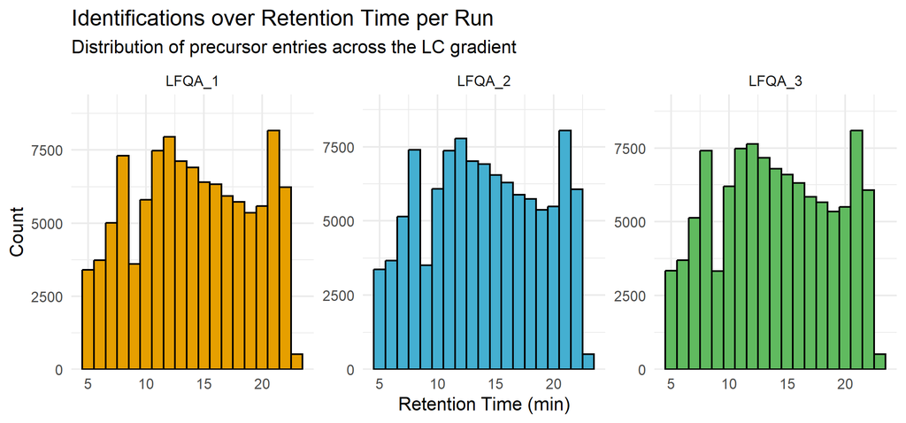

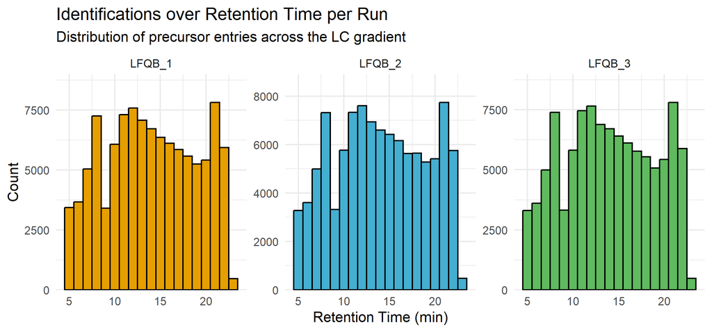

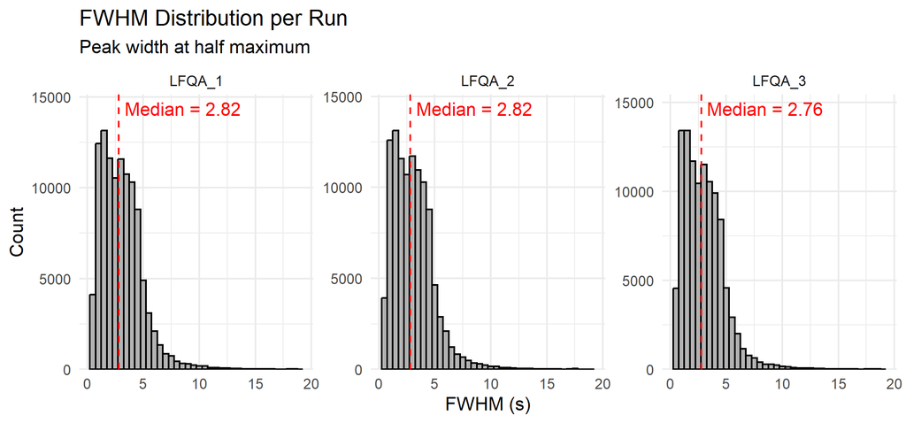

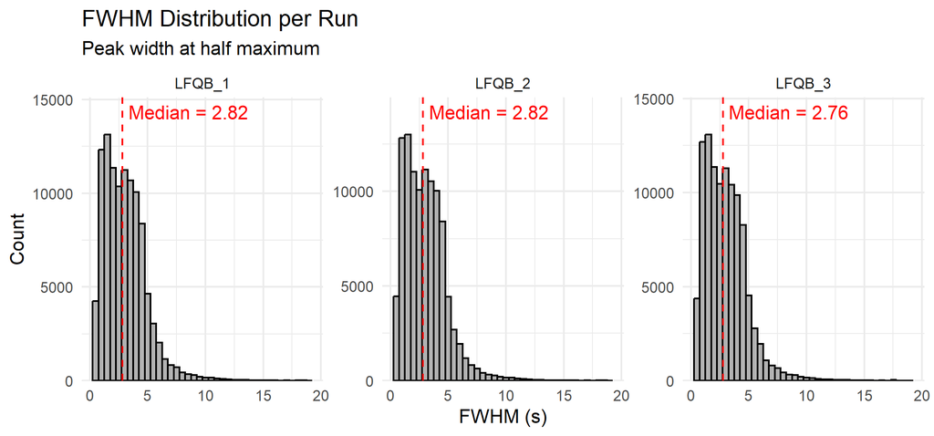

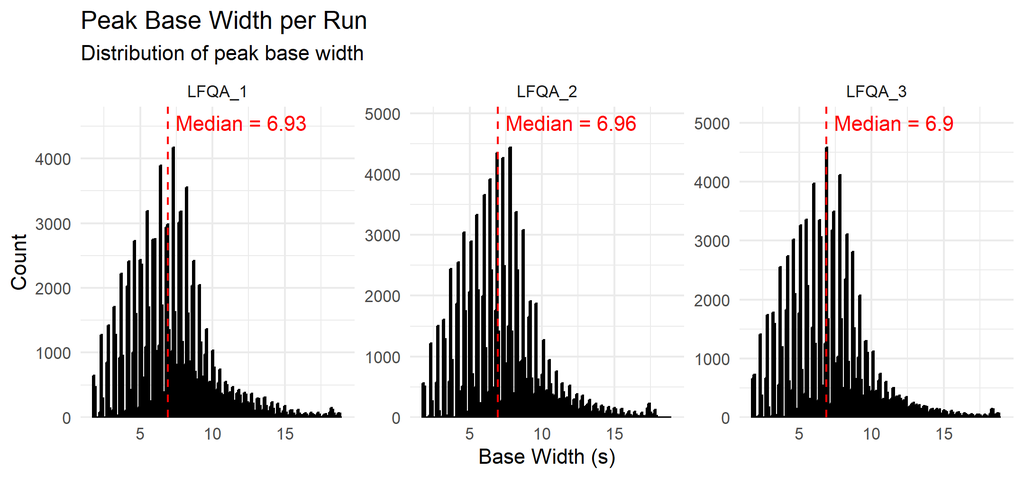

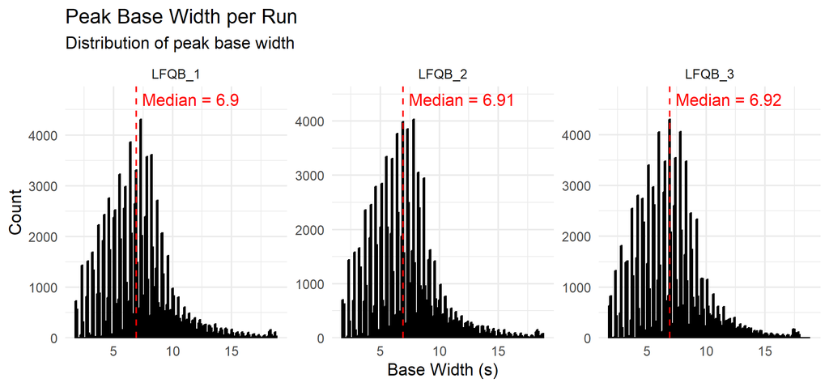

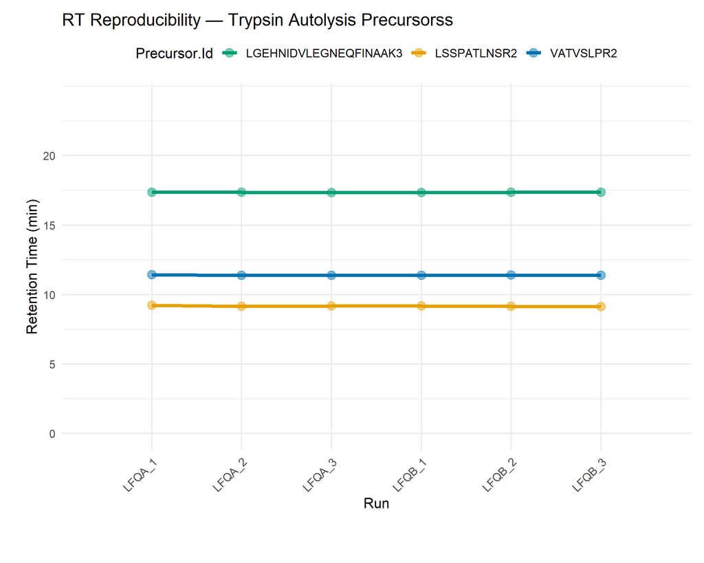

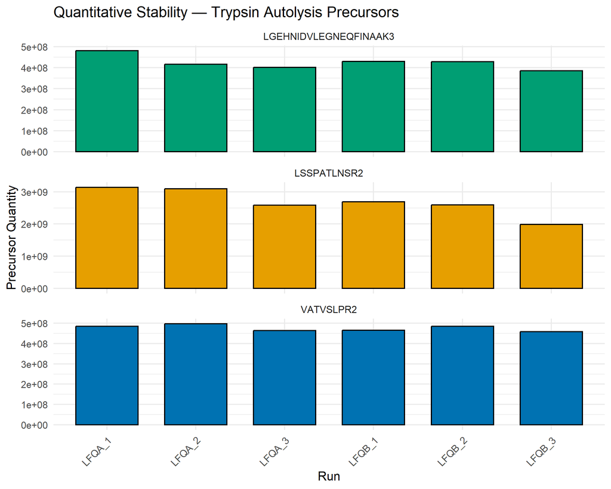

# 6. Mass accuracy

**NoteMass accuracy**

This section summarizes **precursor mass measurement error** across runs to assess systematic bias, distributional spread, and stability over the precursor m/z range.

Mass error is calculated in parts per million (ppm) from `Ms1.Apex.Mz.Delta` relative to `Precursor.Mz`, using observations with positive `Precursor.Quantity` and positive precursor m/z. Per‑run histograms show the mass‑error distribution within a visual range of −10 to 10 ppm, with reference lines indicating zero error and the median error for each run. A complementary profile displays the **median mass error across 50 precursor m/z bins**, providing a robust representation of mass‑dependent trends.

Stable mass accuracy is characterized by distributions and binned median profiles consistently centered around zero. Systematic increases or decreases in median error across the m/z range may indicate calibration drift or mass‑dependent inaccuracies, while broader distributions or irregular profiles may indicate reduced measurement stability. These patterns should be interpreted as QC indicators rather than automatic diagnostic criteria.

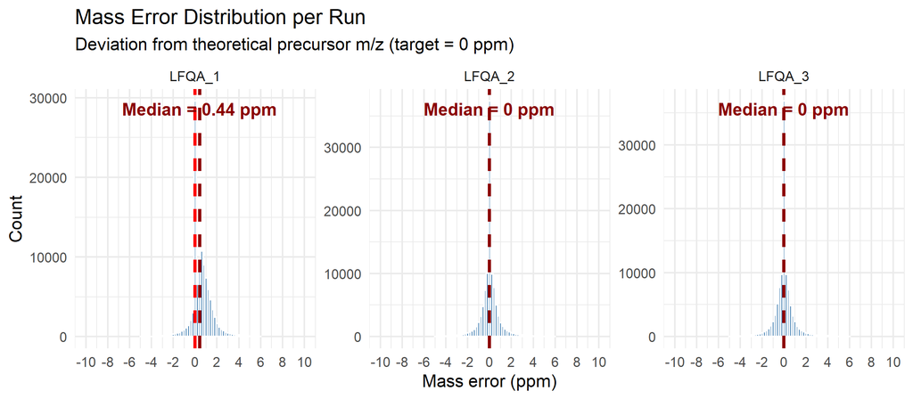

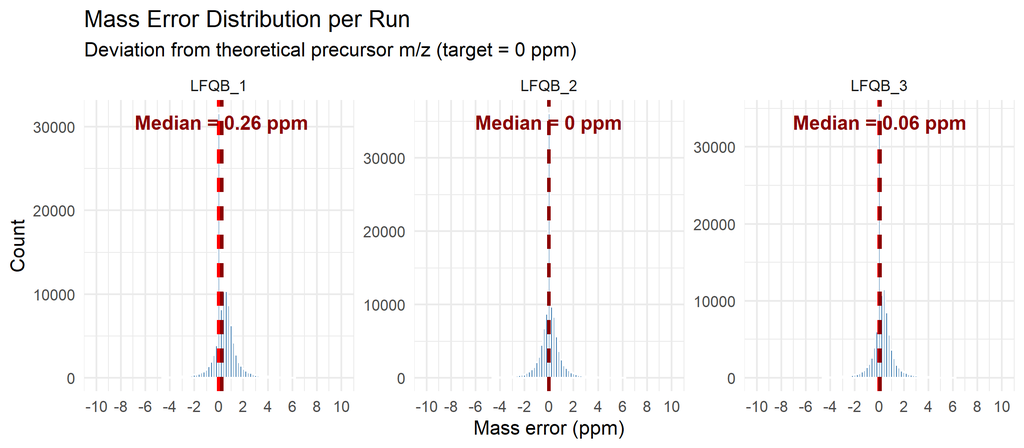

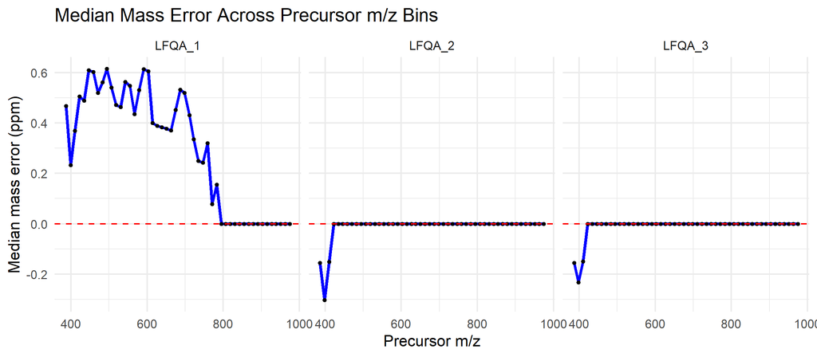

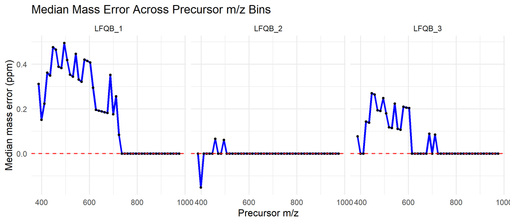

# 7. Quantification quality

**NoteDIA-NN quantification quality**

This section summarizes DIA‑NN quantification quality metrics at the precursor and protein‑group levels, providing complementary views of quantitative quality across runs.

**Quantity.Quality** and **Empirical.Quality** are evaluated jointly at the precursor level.  
**PG.MaxLFQ.Quality** is evaluated at the protein‑group level in relation to the number of distinct precursors supporting each protein group.

The precursor‑level visualization shows the joint distribution of **Quantity.Quality** and **Empirical.Quality** within each run using two‑dimensional bins, with dashed reference lines at 0.5 for both metrics. The protein‑group visualization relates **PG.MaxLFQ.Quality** to the number of distinct supporting precursors on a logarithmic scale, with dashed reference lines at 0.5 and 0.7. These lines are visual references rather than universal acceptance thresholds and support comparison of quality‑metric patterns across runs.

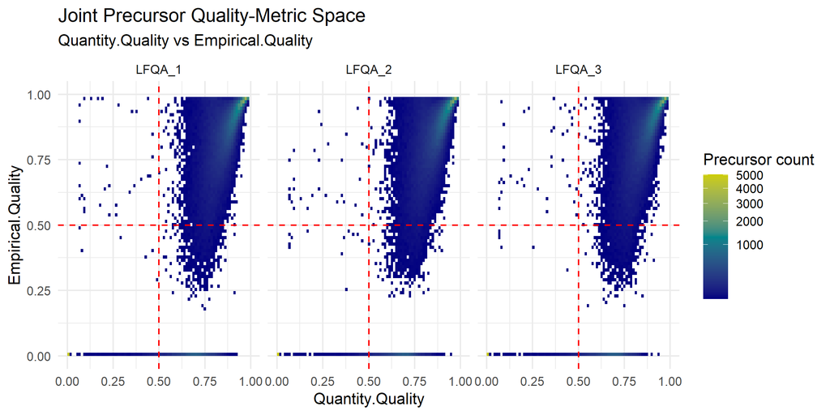

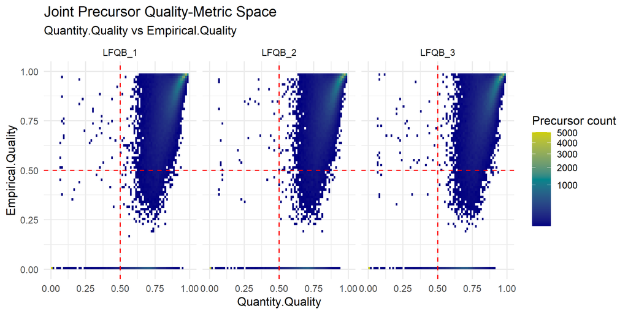

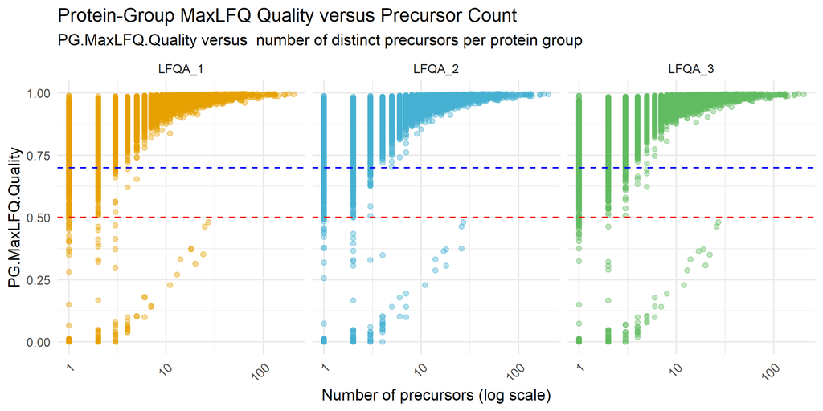

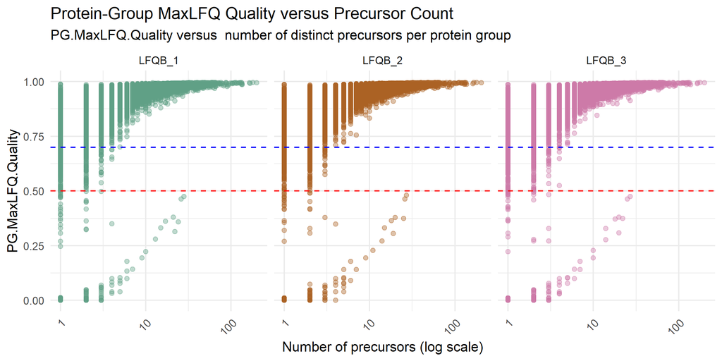

# 8. Intensity and LFQ distribution

**NoteIntensity and LFQ distribution**

This section summarizes **quantitative signal distributions** at the **precursor level** and the **protein‑group level after LFQ normalization**.

Density plots show the distribution of positive, finite `Precursor.Quantity` values across runs on a logarithmic scale, providing an overview of precursor signal range and abundance before protein‑group aggregation. Boxplots summarize positive, finite `PG.MaxLFQ` values, using one value per run and protein group, and show the spread and central tendency of LFQ‑normalized protein‑group signal across runs.

Similar intensity profiles across runs may be consistent with comparable signal loading and quantitative behavior, whereas pronounced shifts or increased dispersion may reflect differences in sample loading, acquisition response, sample composition, or LFQ‑normalized signal distributions. These plots support run‑to‑run comparison but should not be interpreted alone as evidence of normalization performance.

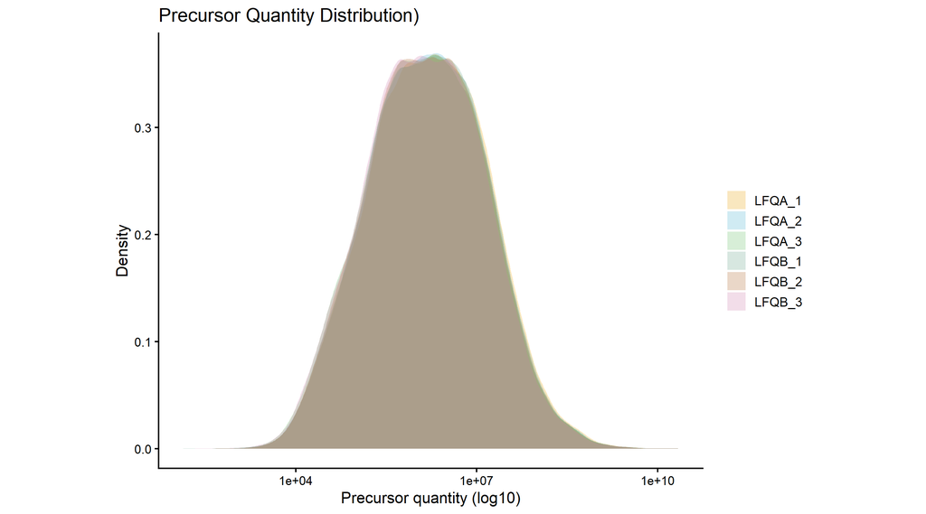

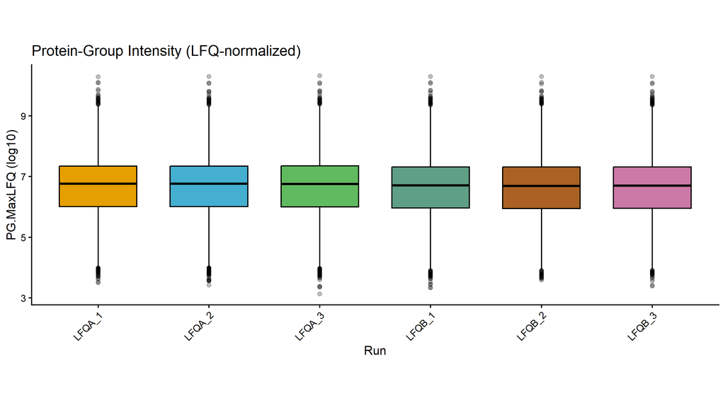

# 9. Data completeness

**NoteData completeness**

This section reports **precursor‑level data completeness**, defined by the availability of `Precursor.Quantity` values across all valid run–precursor combinations.

Global completeness represents the fraction of the complete run × precursor space for which at least one non-missing quantitative value is available. Duplicate entries for the same run and precursor are collapsed before counting, and a combination is considered observed when at least one corresponding `Precursor.Quantity` value is not missing. Run‑level completeness describes the proportion of all valid precursor identifiers with an observed quantitative value in each individual run.

These summaries characterize the availability and consistency of precursor‑level quantitative data across runs and provide context for downstream analyses by highlighting missing values. The run × precursor space is evaluated in long format without materializing a dense quantitative matrix.

Precursor-level data completeness (global)

Computed across all runs and precursors

| Metric | Value |
| --- | --- |
| Number of runs | 6 |
| Number of precursors | 117,807 |
| Total possible values (Run × Precursor) | 706,842 |
| Observed values | 642,026 |
| Data completeness (%) | 90.8 |

Run-level precursor completeness

Percentage of precursors detected per run

| Run | Observed | Total | Completeness_Pct |
| --- | --- | --- | --- |
| LFQA_1 | 108,549 | 117,807 | 92.1 |
| LFQA_2 | 108,186 | 117,807 | 91.8 |
| LFQA_3 | 108,080 | 117,807 | 91.7 |
| LFQB_1 | 106,334 | 117,807 | 90.3 |
| LFQB_2 | 105,204 | 117,807 | 89.3 |
| LFQB_3 | 105,673 | 117,807 | 89.7 |

# 10. Figures of Merit

**NoteFigures of Merit**

This section summarizes key **run-level quality control metrics** in a single table, providing an integrated overview of identification depth, chromatographic performance, retention-time reproducibility, mass accuracy, peptide characteristics, precursor charge states, and contaminant contribution.

The table supports run-to-run comparison and longitudinal instrument monitoring by bringing together complementary indicators of analytical performance. A complete per-run summary is also exported as a CSV file in the Results directory for downstream tracking and trend analysis.

Run-level Figures of Merit

Complete table exported as CSV

[output not shown]

# Reproducibility and session information

Execution environment summary

| Item | Value |
| --- | --- |
| Report generated on | 2026-11-03 14:16:48 |
| R version | R version 4.6.0 (2026-04-24 ucrt) |
| Quarto version | Not detected |
| Number of loaded packages | 19 |

Loaded R packages and versions

| Package | Version |
| --- | --- |
| gtExtras | 0.6.2 |
| gt | 1.3.0 |
| knitr | 1.51 |
| microseq | 2.1.7 |
| rlang | 1.2.0 |
| RColorBrewer | 1.1-3 |
| scales | 1.4.0 |
| ggrepel | 0.9.8 |
| arrow | 24.0.0 |
| lubridate | 1.9.5 |
| forcats | 1.0.1 |
| stringr | 1.6.0 |
| dplyr | 1.2.1 |
| purrr | 1.2.2 |
| readr | 2.2.0 |
| tidyr | 1.3.2 |
| tibble | 3.3.1 |
| ggplot2 | 4.0.3 |
| tidyverse | 2.0.0 |